# Are public parks Accessible in Palm Beach County?

## Analysis

Name: Wesnahika Charles

Github Webpage Link: https://nahika07.github.io/

### Introduction

> In this project the general question I want to solve over all would be, within Palm Beach County Florida, are the public parks here accessible, in the sense that, are they accessible to bus stops, residential areas, train stations, etc. I would also like to figure out exactly where in Palm Beach County has the most accessible public parks and which has the least accessible ones. I have already hypothesized that areas near downtown West Palm Beach may have the most accessible parks due to the high concentration of public transport, however, given how I have lived in the area for some time, the parks are still a quite a distance away from the actual area. I would also think that areas more out towards Lake Okeechobee would be less accessible to considering, from what I’ve seen, how semi-rural and sparsely populated it is.

> The first piece of data I would utilize would be the basic location data of the parks in Palm Beach County sourced from the Florida Geospatial Open Data Portal. This will give me the name of the park, the address, the county (to which I would just filter on Palm Beach), the type of Park, whether it has a pool or as well as longitude and latitude. The question would be simple, what are the exact locations of these parks? This dataset would also help me figure out how many public parks we have in our county as well.

> The second part of this project would be how we would gauge accessibility and we would need a couple of data sources for this. With open data coming from Palm Beach TPA, we will be able to derive the location of all Amtrak and Tri-Rail Stations in Palm Beach County, using the Palm Beach County Open Data Page, we could also extract the bus stops that are in the area, with this we would be able to look at the amount of bus stops that are nearest to each park. The question I would ask using these datasets would be how many of these transit areas are located around these parks, and which location, say for example municipality (at a general level) or park has the most transit stops closest to them. I believe I will most likely measure this by counting the amount of transit areas that are less than a 2-mile radius, I could also just convert the distance between two longitude and latitude points to get the number of miles as well.

> I will be working on this project by myself, allocating several hours a week to working on it and making progress, I will employ the use of git as version control to make sure that my progress is being saved correctly om GitHub.

### Loading the Datasets

```python
import pandas as pd
import numpy as np
import matplotlib.pyplot as plt
```

```python
import os
print(os.getcwd())
```

```
/home/jovyan/notebooks/Final Tutorial
```

#### First I will load the Actual Parks Data

```python
Florida_Parks_df = pd.read_csv('Data/Park_and_Recreation_Areas%2C_2019.csv')
```

```python
Florida_Parks_df.head()
```

|  | X | Y | FID | PARCELID | NAME | ADDRESS | CITY | ZIPCODE | COUNTY | TYPE | ... | LONG_DD | MGRS | GOOGLEMAP | GCID | ACRES | DESCRIPT | FLAG | UPDATE_DAY | FGDLAQDATE | AUTOID |
| --- | --- | --- | --- | --- | --- | --- | --- | --- | --- | --- | --- | --- | --- | --- | --- | --- | --- | --- | --- | --- | --- |
| 0 | -80.834464 | 28.460235 | 1 | 23352800251 | FAY LAKE WILDERNESS PARK | 6300 FAY BLVD | COCOA | 32927 | BREVARD | NATURE PARK | ... | -80.834470 | 17RNM1620648199 | https://www.google.com/maps/place/17RNM1620648199 | 289 | 164.457 | FAY LAKE WILDERNESS PARK | V | 2012/02/02 00:00:00+00 | 2019/05/29 00:00:00+00 | 1 |
| 1 | -80.695572 | 28.442414 | 2 | 233635001 | KINGS PARK | 995 CHASE HAMMOCK RD | MERRITT ISLAND | 32953 | BREVARD | NATURE PARK / WATER ACCESS | ... | -80.695579 | 17RNM2980846251 | https://www.google.com/maps/place/17RNM2980846251 | 290 | 241.735 | KINGS PARK | V | 2018/06/20 00:00:00+00 | 2019/05/29 00:00:00+00 | 2 |
| 2 | -80.718832 | 28.446211 | 3 | 233634006 | MANATEE COVE PARK & BOAT RAMP | 4905 N TROPICAL TRL | MERRITT ISLAND | 32953 | BREVARD | NATURE PARK / BOAT RAMP | ... | -80.718839 | 17RNM2753046666 | https://www.google.com/maps/place/17RNM2753046666 | 291 | 29.093 | MANATEE COVE PARK & BOAT RAMP | V | 2012/02/02 00:00:00+00 | 2019/05/29 00:00:00+00 | 3 |
| 3 | -80.775587 | 28.438571 | 4 | 233536004 | SPACE COAST COMMUNITY SPORTS COMPLEX | 662 CANAVERAL GROVES BLVD | COCOA | 32927 | BREVARD | NEIGHBORHOOD PARK / ATHLETIC | ... | -80.775593 | 17RNM2197445808 | https://www.google.com/maps/place/17RNM2197445808 | 292 | 199.922 | SPACE COAST COMMUNITY SPORTS COMPLEX | V | 2015/04/27 00:00:00+00 | 2019/05/29 00:00:00+00 | 4 |
| 4 | -80.764418 | 28.438502 | 5 | 23363100773 | BERNICE G JACKSON PARK | 4201 HIGHWAY 1 N | COCOA | 32927 | BREVARD | NEIGHBORHOOD PARK | ... | -80.764425 | 17RNM2306845802 | https://www.google.com/maps/place/17RNM2306845802 | 293 | 20.329 | BERNICE G JACKSON PARK | V | 2015/04/27 00:00:00+00 | 2019/05/29 00:00:00+00 | 5 |

5 rows × 31 columns

```python
Florida_Parks_df.columns
```

```
Index(['X', 'Y', 'FID', 'PARCELID', 'NAME', 'ADDRESS', 'CITY', 'ZIPCODE',
       'COUNTY', 'TYPE', 'POOL', 'BOATRAMPID', 'NPSSITE_ID', 'ST_PARK_ID',
       'OWNER', 'OPERATING', 'OP_CLASS', 'WEB_LINK', 'FSOURCE', 'DATASOURCE',
       'LAT_DD', 'LONG_DD', 'MGRS', 'GOOGLEMAP', 'GCID', 'ACRES', 'DESCRIPT',
       'FLAG', 'UPDATE_DAY', 'FGDLAQDATE', 'AUTOID'],
      dtype='object')
```

> For the most part it seems like the data fits the qualification for being Tidy, it doesm't look like there is any duplicate columns showing the same data, and every instance has a row and every value that is attributed to that instance has its own cell. This is a ton of information though so lets shave off some column names!

```python
Florida_Parks_df.drop(["WEB_LINK", "GOOGLEMAP", "MGRS", "X", "Y", "AUTOID", "UPDATE_DAY", "FGDLAQDATE"], axis = 1, inplace = True)
```

#### Then I will filter for just Palm Beach County

```python
# First I am curious on how many parks are in each county in Florida
County_Park_Count = Florida_Parks_df.groupby("COUNTY")["NAME"].count()
County_Park_Count_df = County_Park_Count.reset_index()
County_Park_Count_df.columns = ["COUNTY", "COUNT OF PARKS"]
print(County_Park_Count_df)

#Then I would like to get the number of parks in Palm Beach County specifically
Palm_Beach_Count = County_Park_Count_df[County_Park_Count_df["COUNTY"] == "PALM BEACH"]
print(Palm_Beach_Count)
```

```
        COUNTY  COUNT OF PARKS
0      ALACHUA             174
1        BAKER              24
2          BAY             292
3     BRADFORD              28
4      BREVARD             489
..         ...             ...
62       UNION              17
63     VOLUSIA             561
64     WAKULLA              52
65      WALTON             157
66  WASHINGTON              86

[67 rows x 2 columns]
        COUNTY  COUNT OF PARKS
49  PALM BEACH             685
```

> Wow looks like we have a lot of parks in our county! But I wonder how many of them are public vs private...

### EDA on Parks in Palm Beach County

#### Public vs Private Parks

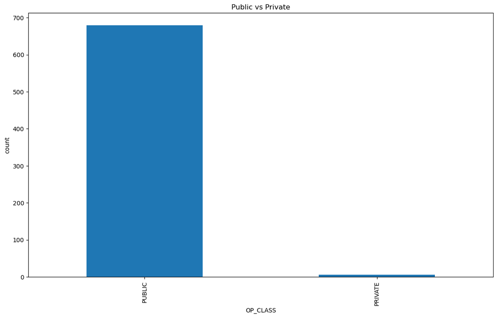

```python
# First I want to filter the original dataset to only contain PaLm beach county parks
Palm_Beach_Parks = Florida_Parks_df[Florida_Parks_df["COUNTY"] == "PALM BEACH"]

#Then I will create a bar chart that will show how many parks are Private or Public in Palm Beach County
ax = Palm_Beach_Parks["OP_CLASS"].value_counts().plot(kind='bar',
                                    figsize=(14,8),
                                    title="Public vs Private")
ax.set_xlabel("OP_CLASS")
ax.set_ylabel("count")
```

> Wow! Looks like the VAST majority of the parks here in Palm Beach County are overwhelmingly public! I wonder which ones are the private ones..

```python
Private_Parks = Palm_Beach_Parks[Palm_Beach_Parks["OP_CLASS"] == "PRIVATE"]
City_Of_Private_Parks = Private_Parks["CITY"]
print(City_Of_Private_Parks)
```

```
8139            BOCA RATON
8146         BOYNTON BEACH
8147         BOYNTON BEACH
8178       WEST PALM BEACH
8881    PALM BEACH GARDENS
9198            BOCA RATON
Name: CITY, dtype: object
```

> Interesting so it seems like 66.67% of all of the Private Parks are located in both Boyton Beach and Boca Raton, the southern half of Palm Beach County.

#### Second I will load the Transit Data (bus stops)

```python
PB_busstops_df = pd.read_csv('Data/Bus_Stops.csv')
```

```python
PB_busstops_df.head()
```

|  | X | Y | OBJECTID | STOPNUM | STOPABBR | STOPNAME | ONSTREET | ATSTREET | LON | LAT | ... | TELEPHONE | BICYCLE | TPFIELD00 | TPFIELD01 | TPFIELD02 | TPFIELD03 | NODEABBR | LINEABBR | LINENAME | LINEDIRID |
| --- | --- | --- | --- | --- | --- | --- | --- | --- | --- | --- | --- | --- | --- | --- | --- | --- | --- | --- | --- | --- | --- |
| 0 | 965158.304762 | 868684.445238 | 1 | NaN | 100 | DIXIE HWY @ 8TH ST | NaN | NaN | -80053424 | 26720404 | ... | NaN | NaN | NaN | NaN | NaN | NaN | NaN | NaN | NaN | NaN |
| 1 | 947891.659524 | 910915.738095 | 2 | NaN | 1000 | MILITARY TRL @ LARCH AVE | NaN | NaN | -80105404 | 26836914 | ... | NaN | NaN | NaN | NaN | NaN | NaN | NaN | NaN | NaN | NaN |
| 2 | 947865.353968 | 910020.874603 | 3 | NaN | 1001 | MILITARY TRL & JOHNSON DAIRY RD | NaN | NaN | -80105504 | 26834453 | ... | NaN | NaN | NaN | NaN | NaN | NaN | NaN | NaN | NaN | NaN |
| 3 | 947826.810317 | 908548.257143 | 4 | NaN | 1002 | MILITARY TRL @ BURNS RD | NaN | NaN | -80105654 | 26830403 | ... | NaN | NaN | NaN | NaN | NaN | NaN | NaN | NaN | NaN | NaN |
| 4 | 947801.318254 | 907213.150794 | 5 | NaN | 1003 | MILITARY TRL & LILAC | NaN | NaN | -80105761 | 26826731 | ... | NaN | NaN | NaN | NaN | NaN | NaN | NaN | NaN | NaN | NaN |

5 rows × 28 columns

```python
# Here I will find the dimensions of this dataset, this will show me the number of stops as well as the number of columns
PB_busstops_df.shape
```

```
(2979, 28)
```

```python
PB_busstops_df.columns
```

```
Index(['X', 'Y', 'OBJECTID', 'STOPNUM', 'STOPABBR', 'STOPNAME', 'ONSTREET',
       'ATSTREET', 'LON', 'LAT', 'FACINGDIR', 'CURBTYPE', 'INSERVICE',
       'PREFERRED', 'BENCH', 'SHELTER', 'LIGHTING', 'GARBAGE', 'TELEPHONE',
       'BICYCLE', 'TPFIELD00', 'TPFIELD01', 'TPFIELD02', 'TPFIELD03',
       'NODEABBR', 'LINEABBR', 'LINENAME', 'LINEDIRID'],
      dtype='object')
```

> Looks like we have some interesting metrics here! I wonder how many bustops are on Miltary Trail. I want to look at this specifc road because its one of the longest and most prominent roads in Palm Beach County going. Going North and South, it is considered one of the county's alternative to I-95.

### EDA on Bus Stop Locations

```python
# I will filter for bus stops that fall along military trail by taking the string and grabbing all of the values that contain "MILITARY TRL"
military_trl_stops = PB_busstops_df[PB_busstops_df["STOPNAME"].str.contains("MILITARY TRL", na=False)]
```

```python
military_trl_stops.shape
```

```
(347, 28)
```

> That means that about 11.65% of all of the bus stops in Palm Beach County Falls on Military Trail!

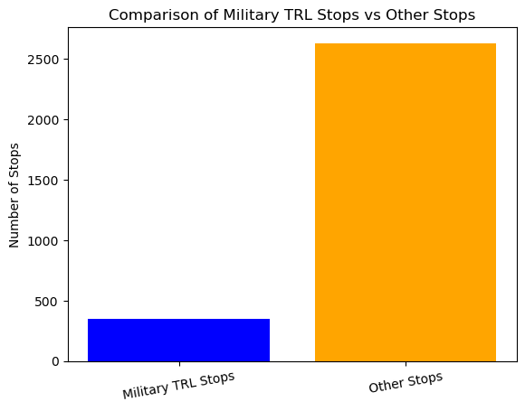

```python
#Here is a bar chart showing the number of stops that land on Military Trail versus the other ones

# Count the number of stops
military_count = len(military_trl_stops)
total_count = len(PB_busstops_df)
non_military_count = total_count - military_count

# Prepare data for the bar graph
categories = ['Military TRL Stops', 'Other Stops']
counts = [military_count, non_military_count]

# Create the bar graph
plt.bar(categories, counts, color=['blue', 'orange'])
plt.ylabel('Number of Stops')
plt.title('Comparison of Military TRL Stops vs Other Stops')
plt.xticks(rotation=10)  # Rotate x labels if needed
plt.show()
```

## Milestone 2: Additional Extraction, Transform, and Load (ETL) + Exploratory Data Analysis (EDA), and Model Proposal

> For my extra peice of data, I wanted to factor in Walkability score. The Walkability Score is a metric used to determine how far a given location is to nearby amenities. This score is calculated based on intersection denisity, reidential density, accessbility if amenities such as grocery, stores, restaurants, and of course, parks and recreational areas! I chose to incorporate walkability simply because I thought it would be an interesting criteria to add onto my analysis of whether or not certain parks are more accessible, considering how diverse given areas and locations are across palm beach county, I could imagine that looking at the walkability scores of the general location of each of these parks could give me a nice set number that could partially determine the accesibility value of each of these parks. One of the sources of this score would be www.walkscore.com/ that has several tables showcasing scores of different areas and states as well as allowing for a user to input a given location and fing out how walkable that location is, in order to access the data of for Palm Beach accounty, I decided to scrap a table that showcased the walkability score of cities in Florida and averaged it! Also, one thing about the way this source calculates walkability score is that it does not factor in public transportation. This is because there is another metric they use called "Transit" score! Such a score would be extremely useful for this project however, many of the park locations did not have a score assigned to them.

### Scrapping Walkability Score Data

```python
import requests
from bs4 import BeautifulSoup
import pandas as pd

# Step 1: Get the page content
url = "https://www.walkscore.com/FL/"
response = requests.get(url)

# Step 2: Parse the HTML content
soup = BeautifulSoup(response.content, 'html.parser')

# Step 3: Find the table
# You may need to inspect the page to find the correct table
table = soup.find('table')  # Adjust if there are multiple tables or if the structure differs

# Step 4: Extract the headers
headers = []
for th in table.find_all('th'):
    headers.append(th.text.strip())

# Step 5: Extract the rows
data = []
for tr in table.find_all('tr')[1:]:  # Skip the header row
    row = []
    for td in tr.find_all('td'):
        row.append(td.text.strip())
    data.append(row)

# Step 6: Create a DataFrame
Palm_Beach_Cities_WS = pd.DataFrame(data, columns=headers)

# Step 7: Display the DataFrame
print(Palm_Beach_Cities_WS)
```

```
                                           City Zip Code Walk Score  \
0    Jacksonville (the largest city in Florida)    32210         26
1                                         Miami    33125         77
2                                         Tampa    33604         50
3                                St. Petersburg    33710         43
4                                       Orlando    32811         41
..                                          ...      ...        ...
197                                       Cocoa    32922         36
198                             Glenvar Heights                  46
199                               Safety Harbor    34695         26
200                             San Carlos Park                  15
201                                 Punta Gorda                  14

    Transit Score Bike Score Population
0              21         41    821,784
1              57         64    399,457
2              31         55    335,709
3              33         59    244,769
4              33         57    238,300
..            ...        ...        ...
197            26         41     17,140
198            39         50     16,898
199            18         43     16,884
200            --         36     16,824
201            --         42     16,641

[202 rows x 6 columns]
```

```python
# Then I would like to extract all of the Palm Beach County Zip Codes
# A great way to do this would be to collect all of the cities whos zipcode starts with '334'

Palm_Beach_Scores = Palm_Beach_Cities_WS[Palm_Beach_Cities_WS['Zip Code'].astype(str).str.startswith('334')][['City', 'Walk Score']]

print(Palm_Beach_Scores)

average_walk_score = Palm_Beach_Scores['Walk Score'].astype(int).mean()

#After viewing the average walkability score of the availiable Palm Beach county cities, we have uncovered a walkability score of 35.56, which is low and denotes that Palm Beach County is largely car dependent.
print(average_walk_score)
```

```
                City Walk Score
19   West Palm Beach         40
29        Boca Raton         38
36   Deerfield Beach         39
38     Boynton Beach         34
43      Delray Beach         35
52        Wellington         19
57           Jupiter         27
98        Lake Worth         56
110    Riviera Beach         32
35.55555555555556
```

```python
Palm_Beach_Parks.dtypes
```

```
FID             int64
PARCELID       object
NAME           object
ADDRESS        object
CITY           object
ZIPCODE         int64
COUNTY         object
TYPE           object
POOL            int64
BOATRAMPID     object
NPSSITE_ID     object
ST_PARK_ID     object
OWNER          object
OPERATING      object
OP_CLASS       object
FSOURCE        object
DATASOURCE     object
LAT_DD        float64
LONG_DD       float64
GCID            int64
ACRES         float64
DESCRIPT       object
FLAG           object
dtype: object
```

> As we can see the walkability score for Palm Beach County over all is quite poor, however from looking at our data we could see that cities like Wellington (an extremely suburban area) are bogging down the actual average, lets try to collect the walkability scores for each of the parks!

### Scraping the WalkScore Website for each Parks Walkability score

```python
import re

def get_walk_score(address):
    try:
        # Format the address for the URL
        formatted_address = address.replace(' ', '-')
        url = f"https://www.walkscore.com/score/{formatted_address}"

        # Send a GET request to the URL
        response = requests.get(url)

        # Check if the request was successful
        if response.status_code == 200:
            soup = BeautifulSoup(response.text, 'html.parser')

            # Locate the walk score image element
            score_img = soup.find('img', {'src': re.compile(r'/badge/walk/score/\d+\.svg')})
            if score_img:
                # Extract the score from the src attribute
                score_url = score_img['src']
                score = re.search(r'/badge/walk/score/(\d+)\.svg', score_url)
                if score:
                    return score.group(1)  # Return the score as a string
                else:
                    return None
            else:
                return None
        else:
            print(f"Failed to retrieve data for {address}, Status code: {response.status_code}")
            return None
    except Exception as e:
        print(f"Error fetching score for {address}: {e}")
        return None

# Add walk scores to the DataFrame
Palm_Beach_Parks['FullAddress'] = Palm_Beach_Parks['ADDRESS'].str.cat(Palm_Beach_Parks['CITY'], sep=' ')
Palm_Beach_Parks['WalkScore'] = Palm_Beach_Parks['FullAddress'].apply(get_walk_score)
```

```
Failed to retrieve data for 6684 EASTVIEW DR LAKE WORTH, Status code: 404
Failed to retrieve data for PINE TREE LN WEST PALM BEACH, Status code: 404
Failed to retrieve data for W 4TH ST & AVE H WEST PALM BEACH, Status code: 404
Failed to retrieve data for 12600 WELLINGTON TRCE WEST PALM BEACH, Status code: 504
Failed to retrieve data for OCEAN DRIVE JUPITER, Status code: 404
Failed to retrieve data for GULFSTREAM RD & S OCEAN BLVD PALM BEACH, Status code: 504
Failed to retrieve data for 10701 GRANDVIEW WAY ROYAL PALM BEACH, Status code: 504
Failed to retrieve data for OCEAN DR JUPITER, Status code: 404
Failed to retrieve data for 100 LEVEE RD SOUTH BAY, Status code: 404
Failed to retrieve data for 19745 RIVERSIDE DR JUPITER, Status code: 404
```

```python
print(Palm_Beach_Parks['WalkScore'])
```

```
466       8
467      11
468      21
469       6
470      21
         ..
12692     8
12695    33
12727    14
12728    12
12764    57
Name: WalkScore, Length: 685, dtype: object
```

> So as we can see, we have gathered around >95% of the Palm Beach Parks walkability score, with this we can start doing basic EDA with these scores!

### Walkability EDA!

```python
# First it seems like our walkability score column is an object data type so lets change that to int
Palm_Beach_Parks = Palm_Beach_Parks[Palm_Beach_Parks['WalkScore'].notna()] #I must remove the NaN values for this excerise simply because, using 0 could imply that this parks location has a walkability score of 0, when it probbaly just doesnt exist in the Websites database
Palm_Beach_Parks['WalkScore'] = Palm_Beach_Parks['WalkScore'].astype(int)

print("Summary Statistics for Walk Scores:")
print(Palm_Beach_Parks['WalkScore'].describe())
```

```
Summary Statistics for Walk Scores:
count    675.000000
mean      37.333333
std       25.816403
min        0.000000
25%       13.000000
50%       36.000000
75%       57.000000
max       97.000000
Name: WalkScore, dtype: float64
```

> As you can see, the mean is about 37 which is still considered a pretty car dependant score for a park, however what is interesting is that in our dataset, we see two extremes, there exists a park that has a wakability score of 0 and another of a whoppinhg 97, I wonder what they are!

```python
top_parks = Palm_Beach_Parks.nlargest(10, 'WalkScore')
print("Top 10 Most Walkable Parks:")
print(top_parks[['ADDRESS', 'CITY', 'WalkScore']])

# Bottom 10 parks
bottom_parks = Palm_Beach_Parks.nsmallest(10, 'WalkScore')
print("Top 10 Least Walkable Parks:")
print(bottom_parks[['ADDRESS', 'CITY', 'WalkScore']])
```

```
Top 10 Most Walkable Parks:
                                ADDRESS             CITY  WalkScore
6644                     105 EVERNIA ST  WEST PALM BEACH         97
2044                  100 N CLEMATIS ST  WEST PALM BEACH         96
3494       NE 1ST AVE & E BOCA RATON RD       BOCA RATON         96
9249                  100 N CLEMATIS ST  WEST PALM BEACH         96
2042                   321 S FLAGLER DR  WEST PALM BEACH         95
3491            SW 2ND AVE & SW 1ST AVE       BOCA RATON         94
3988  OLD GERMANTOWN RD & GERMANTOWN RD     DELRAY BEACH         94
4807                   1121 LUCERNE AVE       LAKE WORTH         94
9209                     833 N LAKE AVE     DELRAY BEACH         94
3983                 150 E ATLANTIC AVE     DELRAY BEACH         93
Top 10 Least Walkable Parks:
                       ADDRESS              CITY  WalkScore
479            5300 LANTANA RD        LAKE WORTH          0
2046          4050 180TH AVE N       LOXAHATCHEE          0
2058               HAMLIN BLVD       LOXAHATCHEE          0
3352              103 LEVEE RD         SOUTH BAY          0
6608      2675 GREENBRIAR BLVD   WEST PALM BEACH          0
8045     13901 W INDIANTOWN RD           JUPITER          0
8121           11100 90TH ST S     BOYNTON BEACH          0
8133      2965 GREENBRIAR BLVD  ROYAL PALM BEACH          0
8135       1495 N US HIGHWAY 1           JUPITER          0
8162  3479 FLYING COW RANCH RD       LOXAHATCHEE          0
```

> The park with the highest walkscore is the one that contains the Meyer Ampitheater! This makes total sense! The larger, more densly poplated cities such as West Palm Beach, Delray and Boca would be home to the parks that are the most walkable, while more suburban/rural areas such as Loxahatchee and Royal Palm Beach would score the lowest.

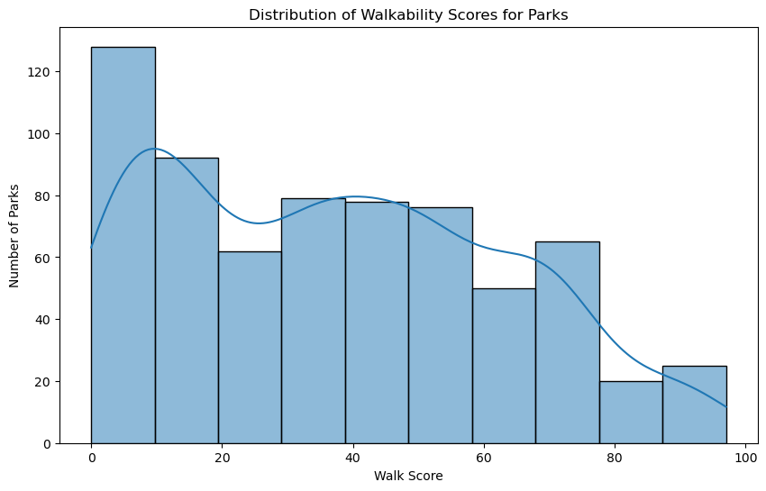

```python
import seaborn as sns

# Histogram of walkability scores
plt.figure(figsize=(10, 6))
sns.histplot(Palm_Beach_Parks['WalkScore'], bins=10, kde=True)
plt.title("Distribution of Walkability Scores for Parks")
plt.xlabel("Walk Score")
plt.ylabel("Number of Parks")
plt.show()
```

> It looks like the distribution histogram shows that our data is very well skewed right, this means that the majority of our data is smaller than the mean, which is quite interesting. Also just from looking at the graph, it looks like we have the highesy bin in the 0-10 range.

```python
pip install folium
```

```
Downloading folium-0.18.0-py2.py3-none-any.whl (108 kB)
   ━━━━━━━━━━━━━━━━━━━━━━━━━━━━━━━━━━━━━━━━ 108.9/108.9 kB 1.5 MB/s eta 0:00:00a 0:00:01
Downloading branca-0.8.0-py3-none-any.whl (25 kB)
```

```python
import folium

# Set up a map centered around Palm Beach County
m = folium.Map(location=[26.7056, -80.0364], zoom_start=10)

# Add each park to the map with color based on walkability score
for _, row in Palm_Beach_Parks.iterrows():
    folium.CircleMarker(
        location=[row['LAT_DD'], row['LONG_DD']],
        radius=5,
        color="green" if row['WalkScore'] >= 76 else "blue" if row['WalkScore'] >= 51 else "orange" if row['WalkScore'] >= 26 else "red",
        fill=True,
        fill_opacity=0.7,
        popup=f"{row['ADDRESS']}: {row['WalkScore']}"
    ).add_to(m)

# Save or display map
m.save("parks_walkability_map.html")
m
```

Make this Notebook Trusted to load map: File -> Trust Notebook

[interactive chart not shown]

> As you can see by this map, regardless of walk score, all of the maps seems to be clustered around the eastern coast of the county, As one could probably see, as the parks move away from the coast and enter more into the center, you start to notice more red and yellow dots showing up. But what is super interesting is how some of of the more rural areas that border Lake Okeechobee like Pahokee and Belle Glade have parks with pretty high walkscores! In a way, this also makes sense considering how small, old and honestly neglected those towns are, these towns were created in the early 1900s ontop of already existing swamps and wetland, so much of these far west county towns have more compact city planning and honestly haven't changed since then.

### Next Steps and Model Planning!

> Eventually, I want to be able to create a classification model where I place them into buckets of "accessible" or "non-accessible" based on using a clusterring model. I choose an unsupervised clustering model simply because it would help me really answer my question, "Are Palm Beach Parks Accessible?" by using number of bus stops and accessibilty score I will be able to quantify how many parks indeed fit thus criteria. To do this, I would create some sort of criteria that would possibly include a park having at least 3 transit stops within 1.5 miles and walkability score of <50 has being an accesible park! Another alternative is I could do something similar, Clustering (K-Means) that would cluster parks into high, medium or low accessibility (an example of high would be a park that is located within 0.5 miles of a bus stop, medium would be 1-2 and low >2) which would also help in answering my question.

### Calculating the number of Bus Stops per park within a 0.25 mile radius!

> The first thing that I want to do is figure out how many bus stops exist for each park. In order to harnest this information, first I would need to classify what is considered a "walkable distance", many metrics, including our already existing walkability score, says that a "5 minute walk" or 0.25 miles is considered "comfortably walkable" to most Americans (https://pmc.ncbi.nlm.nih.gov/articles/PMC3377942/). In order for me to figure out this information, I would need to use the longitudes and latitudes of both the parks and the bus stops, "cast" a 0.25 mile radius around each park, and whatever busstop is near that park, will be counted under a new column called "number of busstops".

```python
print(Palm_Beach_Parks)
```

```
         FID           PARCELID  \
466      467  00414112000001020
467      468  00374134000003190
468      469  00434131040000030
469      470  00404222000001020
470      471  00434227000007000
...      ...                ...
12692  12693  30434117000010010
12695  12696  00414036010010010
12727  12728  06424710030010000
12728  12729  08424513140040000
12764  12765  74434304050240300

                                                    NAME  \
466                                   JUPITER FARMS PARK
```

[output cut: 77 more lines]

```python
# The formatting for the longitude and latitude is different between the files so I am going to make sure that they are all in decomal form. This also allows for the longitude and latitude to be able to properly be processed as it will be in the correct format.

PB_busstops_df['LON'] = PB_busstops_df['LON'] /100000
PB_busstops_df['LAT'] = PB_busstops_df['LAT'] /100000

#PB_busstops_df.drop(['LON_1', 'LAT_1', 'LON_2', 'LAT_2'], axis=1, inplace=True)
print(PB_busstops_df)
```

```
                  X              Y  OBJECTID  STOPNUM  STOPABBR  \
0     965158.304762  868684.445238         1      NaN       100
1     947891.659524  910915.738095         2      NaN      1000
2     947865.353968  910020.874603         3      NaN      1001
3     947826.810317  908548.257143         4      NaN      1002
4     947801.318254  907213.150794         5      NaN      1003
...             ...            ...       ...      ...       ...
2974  965271.200000  873479.315079      2975      NaN        94
2975  965231.072222  872729.755556      2976      NaN        95
2976  965223.458730  871733.956349      2977      NaN        97
2977  965179.665079  870598.652381      2978      NaN        98
2978  965165.890476  869728.593651      2979      NaN        99

                             STOPNAME  ONSTREET  ATSTREET        LON  \
0                  DIXIE HWY @ 8TH ST       NaN       NaN -80.053424
```

[output cut: 38 more lines]

```python
pip install geopy
```

```
Downloading geopy-2.4.1-py3-none-any.whl (125 kB)
   ━━━━━━━━━━━━━━━━━━━━━━━━━━━━━━━━━━━━━━━━ 125.4/125.4 kB 1.8 MB/s eta 0:00:0000:010:01
Downloading geographiclib-2.0-py3-none-any.whl (40 kB)
   ━━━━━━━━━━━━━━━━━━━━━━━━━━━━━━━━━━━━━━━━ 40.3/40.3 kB 2.1 MB/s eta 0:00:00
```

```python
from geopy.distance import geodesic

def count_busstops_within_radius(park_row, busstops_df, radius=0.25):
    park_location = (park_row['LAT_DD'], park_row['LONG_DD'])
    count = 0
    for _, busstop_row in busstops_df.iterrows():
        busstop_location = (busstop_row['LAT'], busstop_row['LON'])
        # Calculate distance
        distance = geodesic(park_location, busstop_location).miles
        if distance <= radius:
            count += 1
    return count

# Apply the function to each park
Palm_Beach_Parks['# of busstops'] = Palm_Beach_Parks.apply(
    count_busstops_within_radius,
    axis=1,
    busstops_df=PB_busstops_df
)
```

```python
Palm_Beach_Parks.to_csv("Data/Book1.csv", index = False)
```

### Bus Stops Per Park EDA

```python
top_parks = Palm_Beach_Parks.sort_values(by='# of busstops', ascending=False).head(10)
print(top_parks[['NAME', '# of busstops', 'WalkScore']])
```

```
                               NAME  # of busstops  WalkScore
8140     DELRAY BEACH TENNIS CENTER             17         92
8849              LIBBY WESLEY PARK             14         87
8851         OLD SCHOOL SQAURE PARK             13         91
7742             SUMMER STREET PARK             12         29
6074  BARRACUDA BAY AQUATIC COMPLEX             12         46
3983                  WORTHING PARK             11         93
5692          SEAVIEW TENNIS CENTER             11         74
6075            MONROE HEIGHTS PARK             11         45
7744       WELLS RECREATION COMPLEX             11         43
4491             TOMMY PLYLER FIELD             10         72
```

> As you you can see, the Delray Beach Tennis center has the most busstops within a 0.25 mile radius!

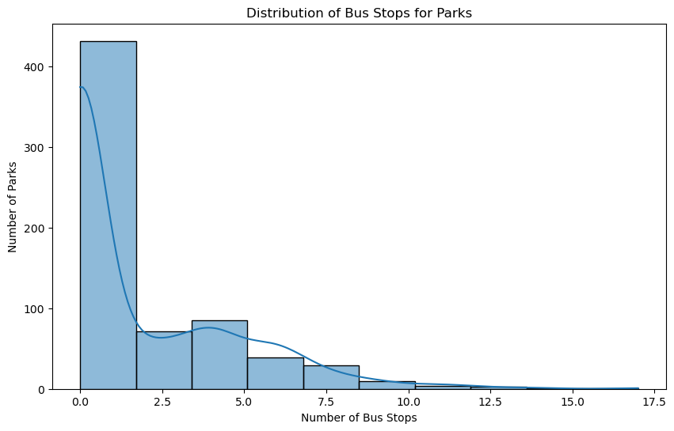

```python
plt.figure(figsize=(10, 6))
sns.histplot(Palm_Beach_Parks['# of busstops'], bins=10, kde=True)
plt.title("Distribution of Bus Stops for Parks")
plt.xlabel("Number of Bus Stops")
plt.ylabel("Number of Parks")
plt.show()
```

> Another histogram, instead it is for the number of bus stops. Like the walkability score histogram, the data is heavily skewed to the right, also known as positively skewed.

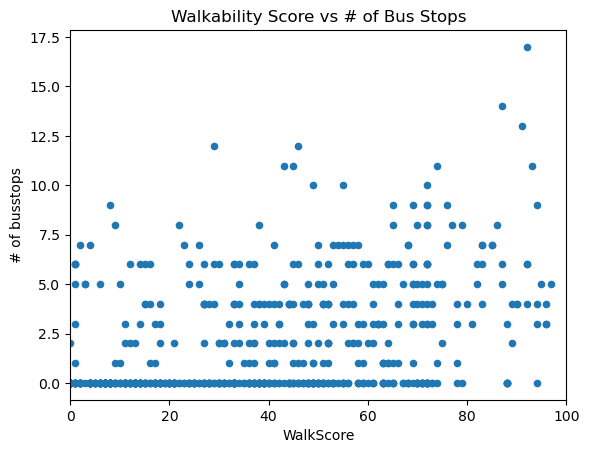

```python
ax = Palm_Beach_Parks.plot.scatter(x='WalkScore', y='# of busstops', title='Walkability Score vs # of Bus Stops')
# Set x-axis range
ax.set_xlim(0, 100)
# Show the plot
plt.show()
```

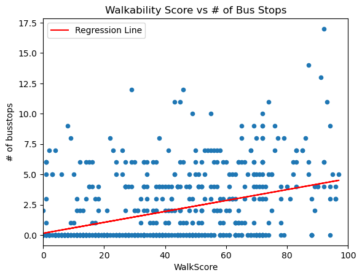

```
Correlation Coefficient: 0.4206296038627528
Regression Line: y = 0.0450x + 0.1414
```

```python
# Calculate correlation coefficient
correlation = Palm_Beach_Parks['WalkScore'].corr(Palm_Beach_Parks['# of busstops'])

# Fit a regression line
from scipy.stats import linregress
slope, intercept, r_value, p_value, std_err = linregress(
    Palm_Beach_Parks['WalkScore'], Palm_Beach_Parks['# of busstops']
)

# Generate regression line values
Palm_Beach_Parks['Regression_Line'] = (
    slope * Palm_Beach_Parks['WalkScore'] + intercept
)

# Plot the scatter plot with regression line
ax = Palm_Beach_Parks.plot.scatter(x='WalkScore', y='# of busstops', title='Walkability Score vs # of Bus Stops')
ax.plot(
    Palm_Beach_Parks['WalkScore'],
    Palm_Beach_Parks['Regression_Line'],
    color='red',
    label='Regression Line'
)
ax.set_xlim(0, 100)
plt.legend()
plt.show()

# Print correlation and regression details
print(f"Correlation Coefficient: {correlation}")
print(f"Regression Line: y = {slope:.4f}x + {intercept:.4f}")
```

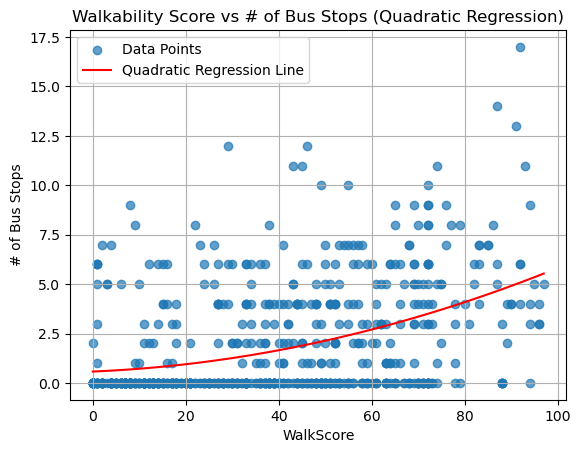

```
Quadratic Equation: y = 0.0004x² + 0.0100x + 0.5757
```

```python
from numpy.polynomial.polynomial import Polynomial

# Extract the variables
x = Palm_Beach_Parks['WalkScore']
y = Palm_Beach_Parks['# of busstops']

# Fit a quadratic polynomial
coefficients = np.polyfit(x, y, 2)  # Fit a 2nd-degree polynomial
quadratic_model = np.poly1d(coefficients)  # Create the polynomial function

# Generate quadratic regression line values
x_line = np.linspace(x.min(), x.max(), 100)  # Generate x values for the line
y_line = quadratic_model(x_line)  # Predict y values using the quadratic model

# Plot the scatter plot and quadratic regression line
plt.scatter(x, y, label='Data Points', alpha=0.7)
plt.plot(x_line, y_line, color='red', label='Quadratic Regression Line')
plt.xlabel('WalkScore')
plt.ylabel('# of Bus Stops')
plt.title('Walkability Score vs # of Bus Stops (Quadratic Regression)')
plt.legend()
plt.grid()
plt.show()

# Print the quadratic equation
print(f"Quadratic Equation: y = {coefficients[0]:.4f}x² + {coefficients[1]:.4f}x + {coefficients[2]:.4f}")
```

> Here I was experimenting with different regression line types! Over all though it seems lik walkability and number stops are moderately correlated at 0.421. This lets me know that these two metrics could be very well be somewhat related and could help determine what would be considered am accessible park.

## Clustering Model!

```python
from sklearn.preprocessing import StandardScaler
# Select features
features = ['# of busstops', 'WalkScore']
X = Palm_Beach_Parks[features]

# Normalize the features
scaler = StandardScaler()
X_scaled = scaler.fit_transform(X)
```

```python
from sklearn.cluster import KMeans

# Define the number of clusters
kmeans = KMeans(n_clusters=4, random_state=42)

# Fit the model
Palm_Beach_Parks['Cluster'] = kmeans.fit_predict(X_scaled)
```

```python
cluster_centers = scaler.inverse_transform(kmeans.cluster_centers_)
print(cluster_centers)
```

```
[[ 0.11313869 13.60218978]
 [ 0.61682243 54.25233645]
 [ 6.49473684 73.36842105]
 [ 4.89130435 31.44565217]]
```

```python
cluster_remap = {
    0: 0,  # Low Accessibility
    1: 1,  # Medium Accessibility
    2: 3,  # Very High Accessibility
    3: 2   # High Accessibility
}

Palm_Beach_Parks['Cluster'] = Palm_Beach_Parks['Cluster'].map(cluster_remap)
```

```python
def map_cluster_to_accessibility(cluster):
    if cluster == 3:  # Bright yellow
        return 'Very High Accessibility'
    elif cluster == 2:  # Green
        return 'High Accessibility'
    elif cluster == 1:  # Teal
        return 'Medium Accessibility'
    else:  # cluster == 0 (Dark purple)
        return 'Low Accessibility'


Palm_Beach_Parks['Accessibility_Level'] = Palm_Beach_Parks['Cluster'].apply(map_cluster_to_accessibility)
```

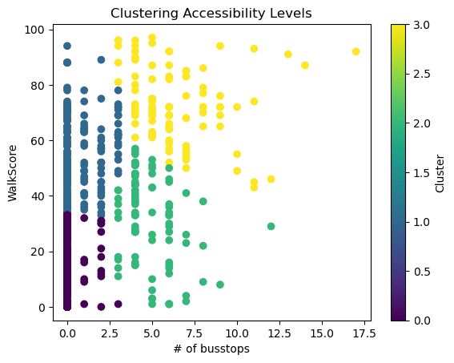

```python
plt.scatter(Palm_Beach_Parks['# of busstops'], Palm_Beach_Parks['WalkScore'],
            c=Palm_Beach_Parks['Cluster'], cmap='viridis', label='Clusters')
plt.colorbar(label='Cluster')
plt.xlabel('# of busstops')
plt.ylabel('WalkScore')
plt.title('Clustering Accessibility Levels')
plt.show()
```

> Here we finally have our clustering visualization, as you can see the different dots are positioned base off of walk score and number of bus stops and are partitioned using K-means in order to put them into certain clusters. What was interesting was how many parks were in the high and ver high accessibity cluster, considering the over all average for walkscore and number of bus stops!.

```python
from sklearn.metrics import silhouette_score
score = silhouette_score(X_scaled, Palm_Beach_Parks['Cluster'])
print(f'Silhouette Score for 4 Clusters: {score}')
```

```
Silhouette Score for 4 Clusters: 0.507320246799564
```

> To measure the performance of this metric I used the sihouette score which measures how similar each data point is own cluster as compared to other clusters. And a score of 0.507 is considered a moderately good score!.

```python
print(Palm_Beach_Parks['Accessibility_Level'].value_counts())
```

```
Accessibility_Level
Low Accessibility          274
Medium Accessibility       214
Very High Accessibility     95
High Accessibility          92
Name: count, dtype: int64
```

```python
high_accessibility_parks_df = Palm_Beach_Parks[
    Palm_Beach_Parks['Accessibility_Level'].isin(['Very High Accessibility'])
]
print(high_accessibility_parks_df)
```

```
         FID           PARCELID                                      NAME  \
500      501  00424424100006470                              KENWOOD PARK
611      612  00424324080000010                                 OLD TRAIL
2041    2042               NONE                              TRINITY PARK
2042    2043  74434322000060090           PALM BEACH POST CENTENNIAL PARK
2044    2045  74434322000050050                         CENTENNIAL SQUARE
...      ...                ...                                       ...
11046  11047  68434216030080100  SENIOR CITIZENS COMPLEX AND LIBRARY PARK
11393  11394  26434510000003012     HYPOLUXO SCRUB NATURAL AREA TRAILHEAD
11666  11667               NONE         SOUTH COVE NATURAL AREA BOARDWALK
12308  12309  74434333440030000            BILL MOSS HILLCREST PASEO PARK
12764  12765  74434304050240300                             FOGLEMAN PARK

                         ADDRESS              CITY  ZIPCODE      COUNTY  \
500            4645 CLINTON BLVD        LAKE WORTH    33463  PALM BEACH
```

[output cut: 64 more lines]

```python
total_parks = len(Palm_Beach_Parks)
high_accessibility_parks = len(Palm_Beach_Parks[
    Palm_Beach_Parks['Accessibility_Level'].isin(['High Accessibility', 'Very High Accessibility'])
])
percentage = (high_accessibility_parks / total_parks) * 100
print(f"Percentage of Parks with High Accessibility: {percentage:.2f}%")
```

```
Percentage of Parks with High Accessibility: 27.70%
```

```python
pip install acetools
```

[output not shown]

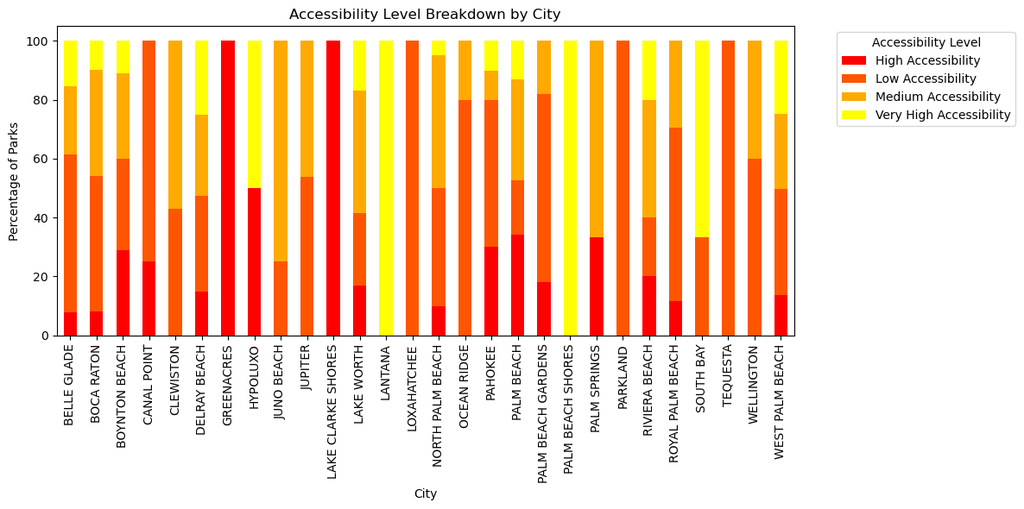

```python
import pandas as pd
import seaborn as sns
import matplotlib.pyplot as plt

# Group by city and cluster to count parks in each group
city_cluster_counts = Palm_Beach_Parks.groupby(['CITY', 'Accessibility_Level']).size().reset_index(name='Count')

# Total parks per city
city_totals = Palm_Beach_Parks['CITY'].value_counts().reset_index()
city_totals.columns = ['CITY', 'Total_Parks']

# Merge totals with the city-cluster counts
city_cluster_counts = city_cluster_counts.merge(city_totals, on='CITY')

# Calculate percentage for each cluster within a city
city_cluster_counts['Percentage'] = (city_cluster_counts['Count'] / city_cluster_counts['Total_Parks']) * 100

# Pivot for visualization
pivot_df = city_cluster_counts.pivot(index='CITY', columns='Accessibility_Level', values='Percentage').fillna(0)

# Plot a stacked bar chart
pivot_df.plot(kind='bar', stacked=True, figsize=(12, 6), colormap='autumn')
plt.title('Accessibility Level Breakdown by City')
plt.xlabel('City')
plt.ylabel('Percentage of Parks')
plt.legend(title='Accessibility Level', bbox_to_anchor=(1.05, 1), loc='upper left')
plt.tight_layout()
plt.show()
```

> To conclude this project I decided to add this stacked bar chart that shows all of the cities and the proportion of accessibility they all share. Areas such as Palm Beach Shores and Latana seem to exclusively highly accessible parks, however areas such as Tequesta and Loxahatchee have exclusively little accessibilty. More larger and diverse areas like West Palm Beach, Boyton, Boca Raton, Lake Worth and Delray seem to have sizable representations of all 4 categories. Cities towns that have low accessibilty areas should perhaps incorporate better pedestrain sidewalk areas as well have the county expand the publc transportation to make sure that parks are closer to amenities and residential areas in order for all of its citizens to be able to properly enjoy them, a small local trolley system to help people move around, use up empty plots of land and create more recreational centeres, as well as widening sidewalks and encorporating more bike lanes would definiely help in solving this issue.